# Machine Learning Course Project

Hayes Williams

Thursday, May 21, 2015

# Introduction

Devices such as Jawbone Up, Nike FuelBand, and Fitbit alllow the collection of a large amount of data about personal activity relatively inexpensively. These type of devices are part of the quantified self movement - a group of enthusiasts who take measurements about themselves regularly to improve their health, to find patterns in their behavior, or because they are tech geeks.

This paper describes the analysis of data from accelerometers on the belt, forearm, arm, and dumbell of 6 participants who were asked to perform barbell lifts correctly and incorrectly in 5 different ways as follows:

- `A`: Exactly according to direction
- `B`: Throwing elbows to the front
- `C`: Lifting only halfway
- `D`: Lowering only halfway
- `E`: Throwing hips to the front

These data were then used to train various algorithms in an effort to determine if a machine learning technique could accurately predict the type of activity performed based on the recorded data from the accelerometers attached to the volunteers.

## Source Data

The training data for this project are available here: https://d396qusza40orc.cloudfront.net/predmachlearn/pml-training.csv. The test data are available https://d396qusza40orc.cloudfront.net/predmachlearn/pml-testing.csv.

## Data Loading

The data was loaded from the source URLs above. During input, the following items: NA, spaces (“”) and #DIV/0! were marked as NA to indicate they were not recognized data.

```r
download.file("http://d396qusza40orc.cloudfront.net/predmachlearn/pml-training.csv",
              "pml-training.csv")
download.file("http://d396qusza40orc.cloudfront.net/predmachlearn/pml-testing.csv",
              "pml-testing.csv")

pml_train <- read.csv("pml-training.csv", na.strings=c("NA","","#DIV/0!"))
pml_test <- read.csv("pml-testing.csv", na.strings=c("NA","","#DIV/0!"))
```

## Data Cleansing

### NA Columns Removed

After load, the data was cleansed before analysis. All columns were evaluated to determine what percentage NA’s they contained. Columns which were determined to have >95% NA’s were removed from the analysis set in both the test and train data sets. The specific steps were detailed in the comments below.

```r
library(dplyr)
# Interpretation of dplyr chain notation:
# na_cols_df <- Take the training data set and
#               Summarise each column by counting na's and dividing by length
#               Transposing the wide column format with one row to narrow
#               Cast as a data frame because it comes out as a matrix
#               Move the rownames into an explicit column variable
#               Subset only those with > 95% nulls
#               Select only the rowname column
na_cols_df <- pml_train %>%
              summarise_each(funs(count=sum(is.na(.))/length(.))) %>%
              t %>%
              as.data.frame %>%
              add_rownames %>%
              filter(V1>0.95) %>%
              select(rowname)
na_col <- c(na_cols_df$rowname, "X") # Add the first column row name

# Remove the columns identified in na_col from train and test subsets
pml_train_subset <- select(pml_train, -one_of(na_col))
pml_test_subset <- select(pml_test, -one_of(na_col))
```

### Near Zero Covariates Removed

After the initial cleansing step of removing NAs, the caret library was loaded and a check for near zero covariates was performed. The column `new_window` shows as a near zero covariate. This column was removed. A compound timestamp was added and other non-motion related variables such as `raw_timestamp_part_1`, `raw_timestamp_part_2`, `cvtd_timestamp`, `new_window` and `num_window` were also removed from the test and train subsets.

```r
library(caret)
nearZeroVar(pml_train_subset, saveMetrics=TRUE)
```

```
##                      freqRatio percentUnique zeroVar   nzv
## user_name             1.100679    0.03057792   FALSE FALSE
## raw_timestamp_part_1  1.000000    4.26562022   FALSE FALSE
## raw_timestamp_part_2  1.000000   85.53154622   FALSE FALSE
## cvtd_timestamp        1.000668    0.10192641   FALSE FALSE
## new_window           47.330049    0.01019264   FALSE  TRUE
## num_window            1.000000    4.37264295   FALSE FALSE
## roll_belt             1.101904    6.77810621   FALSE FALSE
## pitch_belt            1.036082    9.37722964   FALSE FALSE
## yaw_belt              1.058480    9.97349913   FALSE FALSE
## total_accel_belt      1.063160    0.14779329   FALSE FALSE
## gyros_belt_x          1.058651    0.71348486   FALSE FALSE
## gyros_belt_y          1.144000    0.35164611   FALSE FALSE
## gyros_belt_z          1.066214    0.86127816   FALSE FALSE
## accel_belt_x          1.055412    0.83579655   FALSE FALSE
## accel_belt_y          1.113725    0.72877383   FALSE FALSE
## accel_belt_z          1.078767    1.52379982   FALSE FALSE
## magnet_belt_x         1.090141    1.66649679   FALSE FALSE
## magnet_belt_y         1.099688    1.51870350   FALSE FALSE
## magnet_belt_z         1.006369    2.32901845   FALSE FALSE
## roll_arm             52.338462   13.52563449   FALSE FALSE
## pitch_arm            87.256410   15.73234125   FALSE FALSE
## yaw_arm              33.029126   14.65701763   FALSE FALSE
## total_accel_arm       1.024526    0.33635715   FALSE FALSE
## gyros_arm_x           1.015504    3.27693405   FALSE FALSE
## gyros_arm_y           1.454369    1.91621649   FALSE FALSE
## gyros_arm_z           1.110687    1.26388747   FALSE FALSE
## accel_arm_x           1.017341    3.95984099   FALSE FALSE
## accel_arm_y           1.140187    2.73672409   FALSE FALSE
## accel_arm_z           1.128000    4.03628580   FALSE FALSE
## magnet_arm_x          1.000000    6.82397309   FALSE FALSE
## magnet_arm_y          1.056818    4.44399144   FALSE FALSE
## magnet_arm_z          1.036364    6.44684538   FALSE FALSE
## roll_dumbbell         1.022388   84.20650290   FALSE FALSE
## pitch_dumbbell        2.277372   81.74498012   FALSE FALSE
## yaw_dumbbell          1.132231   83.48282540   FALSE FALSE
## total_accel_dumbbell  1.072634    0.21914178   FALSE FALSE
## gyros_dumbbell_x      1.003268    1.22821323   FALSE FALSE
## gyros_dumbbell_y      1.264957    1.41677709   FALSE FALSE
## gyros_dumbbell_z      1.060100    1.04984201   FALSE FALSE
## accel_dumbbell_x      1.018018    2.16593619   FALSE FALSE
## accel_dumbbell_y      1.053061    2.37488533   FALSE FALSE
## accel_dumbbell_z      1.133333    2.08949139   FALSE FALSE
## magnet_dumbbell_x     1.098266    5.74864948   FALSE FALSE
## magnet_dumbbell_y     1.197740    4.30129447   FALSE FALSE
## magnet_dumbbell_z     1.020833    3.44511263   FALSE FALSE
## roll_forearm         11.589286   11.08959331   FALSE FALSE
## pitch_forearm        65.983051   14.85577413   FALSE FALSE
## yaw_forearm          15.322835   10.14677403   FALSE FALSE
## total_accel_forearm   1.128928    0.35674243   FALSE FALSE
## gyros_forearm_x       1.059273    1.51870350   FALSE FALSE
## gyros_forearm_y       1.036554    3.77637346   FALSE FALSE
## gyros_forearm_z       1.122917    1.56457038   FALSE FALSE
## accel_forearm_x       1.126437    4.04647844   FALSE FALSE
## accel_forearm_y       1.059406    5.11160942   FALSE FALSE
## accel_forearm_z       1.006250    2.95586586   FALSE FALSE
## magnet_forearm_x      1.012346    7.76679238   FALSE FALSE
## magnet_forearm_y      1.246914    9.54031189   FALSE FALSE
## magnet_forearm_z      1.000000    8.57710733   FALSE FALSE
## classe                1.469581    0.02548160   FALSE FALSE
```

```r
drop_cols <- c("raw_timestamp_part_1", "raw_timestamp_part_2", "cvtd_timestamp",
               "new_window", "num_window")

pml_train_subset2 <- pml_train_subset %>%
                     mutate(timestamp=(raw_timestamp_part_1 +
                                       raw_timestamp_part_2/10^6)) %>%
                     select(-one_of(drop_cols))

pml_test_subset2 <- pml_test_subset %>%
                         mutate(timestamp=(raw_timestamp_part_1 +
                                       raw_timestamp_part_2/10^6)) %>%
                     select(-one_of(drop_cols))
```

# Analysis and model building.

## Separation of Train Data Set

```r
set.seed(8888)
pml_inTrain = createDataPartition(y=pml_train_subset2$classe, p=0.7, list=FALSE)
training = pml_train_subset2[pml_inTrain,]
testing = pml_train_subset2[-pml_inTrain,]
dim(training)
```

```
## [1] 13737    55
```

## Classification Tree

The classification Tree methodology was initially used to model the data as shown below.

```r
library(rattle)
class_tree_model_fit <- train(classe ~ ., data = training, method="rpart")
print(class_tree_model_fit, digits=3)
```

[output not shown]

```r
print(class_tree_model_fit$finalModel, digits=3)
```

[output not shown]

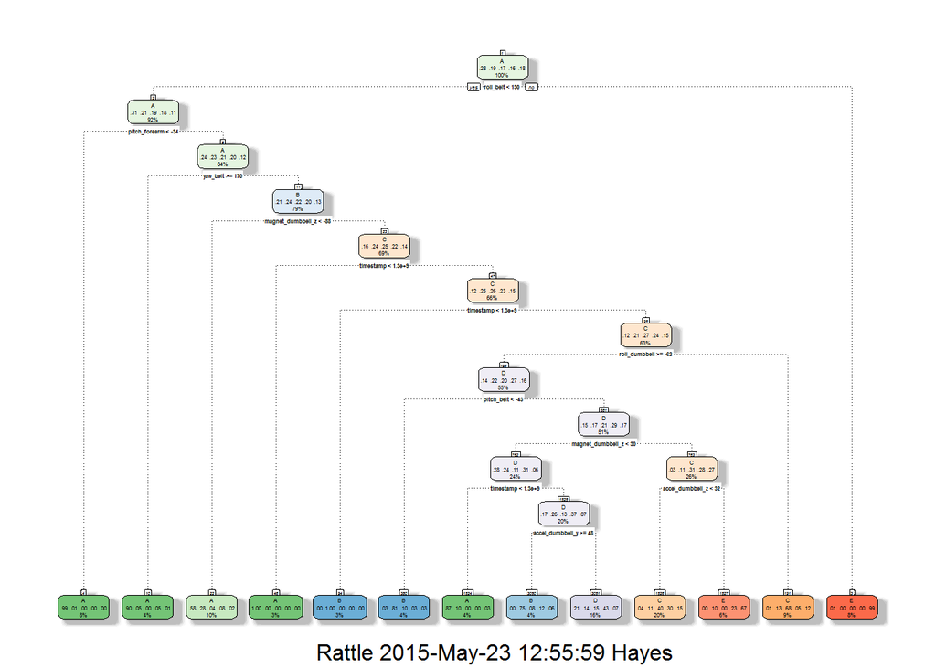

```r
fancyRpartPlot(class_tree_model_fit$finalModel)
```

A tree model is shown which separates the prediction by contributing variable.

```r
class_tree_predictions <- predict(class_tree_model_fit, newdata=testing)
print(confusionMatrix(class_tree_predictions, testing$classe), digits=4)
```

[output not shown]

When applied against the data set `testing` which was the portion of the original training set left aside a relatively disappointing predicative accuracy of 66% was identified as shown above and indicated by the confusion matrix.

## Random Forest

A Random Forest model was attempted next. This model included a cross validation structure of 4 parts.

```r
random_forest_model_fit <- train(training$classe ~ ., method="rf",
                                 trControl=trainControl(method = "cv",
                                                        number = 4),
                                 prox=TRUE,
                                 data=training)
print(random_forest_model_fit, digits=3)
```

```
## Random Forest
##
## 13737 samples
##    54 predictor
##     5 classes: 'A', 'B', 'C', 'D', 'E'
##
## No pre-processing
## Resampling: Cross-Validated (4 fold)
##
## Summary of sample sizes: 10301, 10303, 10304, 10303
##
## Resampling results across tuning parameters:
##
##   mtry  Accuracy  Kappa  Accuracy SD  Kappa SD
##    2    0.994     0.992  0.002765     0.003498
##   30    0.998     0.997  0.000766     0.000969
##   58    0.995     0.994  0.001223     0.001547
##
## Accuracy was used to select the optimal model using  the largest value.
## The final value used for the model was mtry = 30.
```

```r
predictions <- predict(random_forest_model_fit, newdata=testing)
print(confusionMatrix(predictions, testing$classe), digits=4)
```

```
## Confusion Matrix and Statistics
##
##           Reference
## Prediction    A    B    C    D    E
##          A 1674    3    0    0    0
##          B    0 1136    1    0    0
##          C    0    0 1025    1    0
##          D    0    0    0  961    0
##          E    0    0    0    2 1082
##
## Overall Statistics
##
##                Accuracy : 0.9988
##                  95% CI : (0.9976, 0.9995)
##     No Information Rate : 0.2845
##     P-Value [Acc > NIR] : < 2.2e-16
##
##                   Kappa : 0.9985
##  Mcnemar's Test P-Value : NA
##
## Statistics by Class:
##
##                      Class: A Class: B Class: C Class: D Class: E
## Sensitivity            1.0000   0.9974   0.9990   0.9969   1.0000
## Specificity            0.9993   0.9998   0.9998   1.0000   0.9996
## Pos Pred Value         0.9982   0.9991   0.9990   1.0000   0.9982
## Neg Pred Value         1.0000   0.9994   0.9998   0.9994   1.0000
## Prevalence             0.2845   0.1935   0.1743   0.1638   0.1839
## Detection Rate         0.2845   0.1930   0.1742   0.1633   0.1839
## Detection Prevalence   0.2850   0.1932   0.1743   0.1633   0.1842
## Balanced Accuracy      0.9996   0.9986   0.9994   0.9984   0.9998
```

This model produced an excellent accuracy of about 99%. Virtually the entire testing set was identified correctly.

## Boosting

Finally a boosting model was used as an alternative methodology.

```r
gbm_boosting_model_fit <- train(training$classe ~ ., method="gbm",
                                 verbose=FALSE, data=training)
print(gbm_boosting_model_fit, digits=3)
```

```
## Stochastic Gradient Boosting
##
## 13737 samples
##    54 predictor
##     5 classes: 'A', 'B', 'C', 'D', 'E'
##
## No pre-processing
## Resampling: Bootstrapped (25 reps)
##
## Summary of sample sizes: 13737, 13737, 13737, 13737, 13737, 13737, ...
##
## Resampling results across tuning parameters:
##
##   interaction.depth  n.trees  Accuracy  Kappa  Accuracy SD  Kappa SD
##   1                   50      0.810     0.759  0.007534     0.00954
##   1                  100      0.881     0.850  0.005660     0.00716
##   1                  150      0.913     0.890  0.004938     0.00622
##   2                   50      0.926     0.907  0.006108     0.00774
##   2                  100      0.974     0.968  0.002862     0.00363
##   2                  150      0.991     0.988  0.001911     0.00242
##   3                   50      0.965     0.955  0.004388     0.00556
##   3                  100      0.993     0.991  0.001961     0.00248
##   3                  150      0.997     0.996  0.000858     0.00109
##
## Tuning parameter 'shrinkage' was held constant at a value of 0.1
##
## Tuning parameter 'n.minobsinnode' was held constant at a value of 10
## Accuracy was used to select the optimal model using  the largest value.
## The final values used for the model were n.trees = 150,
##  interaction.depth = 3, shrinkage = 0.1 and n.minobsinnode = 10.
```

```r
predictions <- predict(gbm_boosting_model_fit, newdata=testing)
print(confusionMatrix(predictions, testing$classe), digits=4)
```

```
## Confusion Matrix and Statistics
##
##           Reference
## Prediction    A    B    C    D    E
##          A 1673    3    0    0    0
##          B    1 1136    0    0    0
##          C    0    0 1026    2    1
##          D    0    0    0  960    0
##          E    0    0    0    2 1081
##
## Overall Statistics
##
##                Accuracy : 0.9985
##                  95% CI : (0.9971, 0.9993)
##     No Information Rate : 0.2845
##     P-Value [Acc > NIR] : < 2.2e-16
##
##                   Kappa : 0.9981
##  Mcnemar's Test P-Value : NA
##
## Statistics by Class:
##
##                      Class: A Class: B Class: C Class: D Class: E
## Sensitivity            0.9994   0.9974   1.0000   0.9959   0.9991
## Specificity            0.9993   0.9998   0.9994   1.0000   0.9996
## Pos Pred Value         0.9982   0.9991   0.9971   1.0000   0.9982
## Neg Pred Value         0.9998   0.9994   1.0000   0.9992   0.9998
## Prevalence             0.2845   0.1935   0.1743   0.1638   0.1839
## Detection Rate         0.2843   0.1930   0.1743   0.1631   0.1837
## Detection Prevalence   0.2848   0.1932   0.1749   0.1631   0.1840
## Balanced Accuracy      0.9993   0.9986   0.9997   0.9979   0.9993
```

This also produced an excellent 99% accuracy level as indicated by the above confusion matrix and Accuracy rating.

# Conclusions

The random forest and boosting methods produced excellent predictive results for this problem data set. Focusing on the Random Forest results for example, the accuracy was essentially 99% on the `testing` data set held aside from the model fitting excercise.

# Submission Answers for Automated Testing

For the final predictive approach the random forest and boosting methodologies were used to predict the automated submission test set. Fortunatly both gave exactly the same answers for this test set so the fact that `pml_write_files` is called twice and overwrites the submission files isn’t a problem. The vector returned by `sapply` comes out as a factor variable so the `sapply` function is used to move each element to a character to heed the warning in the submission instructions.

```r
pml_write_files <- function(x){
  n = length(x)
  for(i in 1:n){
    filename = paste0("problem_id_",i,".txt")
    write.table(x[i],file=filename,quote=FALSE,row.names=FALSE,col.names=FALSE)
  }
}

predictions_rf <- sapply(predict(random_forest_model_fit,
                                  pml_test_subset2, type = "raw"), as.character)
pml_write_files(predictions_rf)

predictions_boost <- sapply(predict(gbm_boosting_model_fit,
                                  pml_test_subset2, type = "raw"), as.character)
pml_write_files(predictions_boost)
```